# To block, or not to block…

## Motivation

### Imagine something is affecting our response variable, $Y_{i=1,2,3,\cdots,n}$, but is unrelated to our treatments, $T_{i=1,2,3,\cdots,p}$.

> For example, say we are interested in the effect of soybean consumption,

$T_i = \begin{cases} 0, \text{ if the }i^{th }\text{ unit receives the control/no soybeans}\\ 1, \text{ if the}\;i^{th }\text{ unit receives the treatment/soybeans} \end{cases}$

> on estrogen levels, $\hat{Y}$, in a population of subjects.

> Assume that (i) there is no treament effect and (ii) gender may affect estrogen levels, $\hat{Y}$, but is unrelated to our treatment, $T_i$, such that:

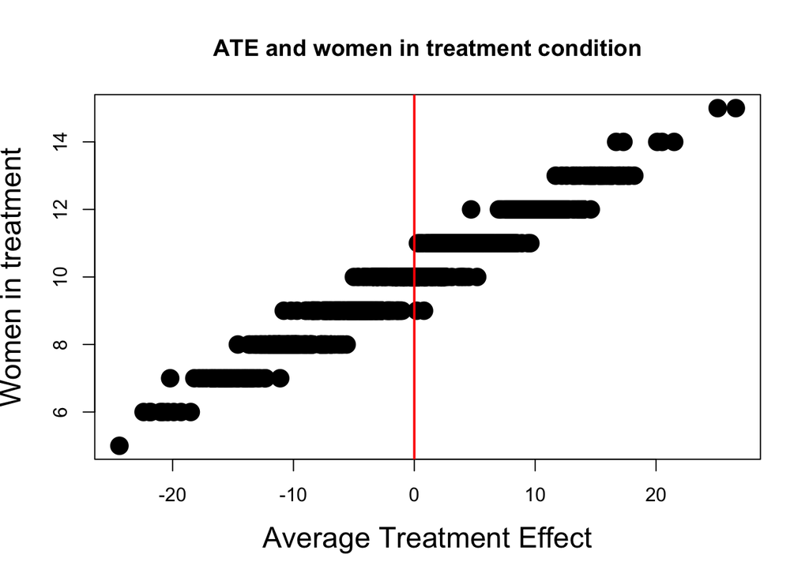

> Imagine we don’t know that gender affects $\hat{Y}$ *a-priori*- we could assign all (or even just 12/20) women to treatment, $T_{i=1}$, and all men to control, $T_{i=0}$.

> In this case we might detect a *treatment effect*- but is it meaningful?

### To address this variation in $\hat{Y}$, that is unrelated to the treatment, $T_i$, we can block *on* gender.

> Now, imagine that there is a treatment effect, let’s look at the precision of our estimates with and without blocking:

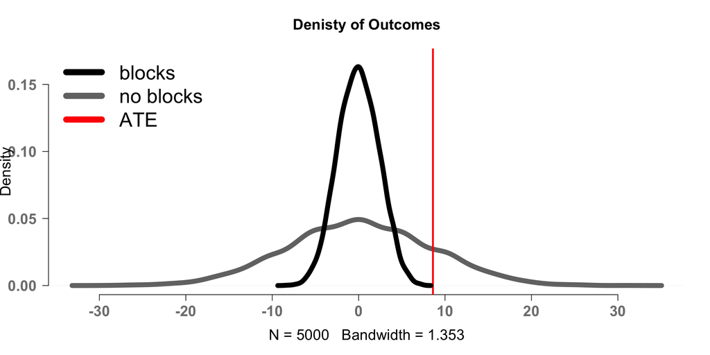

> Note that if we assign treatments within each block, gender, the precision of our estimate is less variable than when we randomize across genders.

### Blocking also effects our inferences from linear models.

> For example:

```
##
## Results with and without blocks
## ================================================================
##                                  Dependent variable:
##                       ------------------------------------------
##                                        outcomes
##                                 (1)                  (2)
## ----------------------------------------------------------------
## treatment                    8.500***               8.500
##                               (1.880)              (8.320)
##
## as.factor(group)Woman        50.000***
##                               (1.880)
##
## Constant                     11.250***            36.250***
##                               (1.628)              (5.883)
##
## ----------------------------------------------------------------
## Observations                    40                    40
## R2                             0.952                0.027
## Adjusted R2                    0.949                0.001
## Residual Std. Error       5.945 (df = 37)      26.312 (df = 38)
## F Statistic           363.951*** (df = 2; 37) 1.044 (df = 1; 38)
## ================================================================
## Note:                                *p<0.1; **p<0.05; ***p<0.01
```

> Note the size of the standard errors, $t$-values, and *p*-values in each model, with and without blocking!

### Finally, blocking influences the efficiency of our designs:

> Efficiency with blocking:

$$E_{wb}= \frac{1}{(n-(b-1)-(t-1)-1) \cdot (MSE_e)}$$

```
## [1] 11690.62
```

> Efficiency without blocking:

$$E_{nb} = \frac{1}{(n-t) \cdot (MSE_e + MSE_b)}$$

```
## [1] 11411.09
```

> Efficiency =
> $$\frac{E_{wb}}{E_{nb}}$$

```
## [1] 1.024496
```

> The design without blocks (CRD) needs $n = n \cdot 1.02 \approx 41$ to achieve the same efficiency as the design with blocks (RCBD).